# Раздел с трансферным обучением

```python
from dataclasses import dataclass
from typing import Tuple, Dict, Any, Optional
from pathlib import Path
import os
import yaml
from dataclasses import dataclass
from pathlib import Path
from typing import Optional, Tuple
from roboflow import Roboflow
import logging
import time
import torch
import torchvision.transforms as transforms
from torch.utils.data import DataLoader, Dataset, random_split
from torchvision.datasets import ImageFolder
from typing import Tuple, Dict, List
import torchvision.models as models
from pathlib import Path
import matplotlib.pyplot as plt
from PIL import Image
import torch
import torch.nn as nn
import torch.optim as optim
from torch.utils.data import DataLoader
from torch.optim.lr_scheduler import ReduceLROnPlateau
import traceback
import matplotlib.pyplot as plt
import seaborn as sns
from sklearn.metrics import (
    classification_report,
    confusion_matrix,
    precision_recall_fscore_support
)
import json
from sklearn.metrics import confusion_matrix, precision_recall_fscore_support
from abc import ABC, abstractmethod
from typing import Dict, List, Optional, Any, Tuple, Protocol
import pickle
import numpy as np
```

```python
logging.basicConfig(
    level=logging.INFO,
    format='%(asctime)s - %(levelname)s - %(message)s'
)
logger = logging.getLogger(__name__)
```

## 1. Конфигурация

### 1.3 Конфигурация обучения (TrainingConfig)

Настройки процесса обучения включают количество эпох, механизмы раннего останова и адаптивного изменения learning rate для оптимизации процесса обучения.

```python
@dataclass
class DataConfig:
    dataset_path: str = "./dataset"
    image_size: Tuple[int, int] = (224, 224)
    batch_size: int = 32
    validation_split: float = 0.2
    test_split: float = 0.15
    random_seed: int = 42

@dataclass
class ModelConfig:
    architecture: str = "resnet50"
    pretrained: bool = True
    freeze_base: bool = True
    num_classes: int = 5
    dropout_rate: float = 0.1
    learning_rate: float = 0.001

@dataclass
class TrainingConfig:
    epochs: int = 50
    early_stopping_patience: int = 10
    reduce_lr_patience: int = 5
    reduce_lr_factor: float = 0.5
    min_lr: float = 1e-7

@dataclass
class RoboflowConfig:
    api_key: str = "7fwRxe7BbpO6YkhH7dW7"
    workspace: str = "roboflow-universe-projects"
    project_name: str = "banana-ripeness-classification"
    version: int = 5
    target_dir: str = "./dataset"
    format_type: str = "folder"
    overwrite: bool = False
```

## 2. Загрузка и подготовка данных

### 2.2 Обработчик данных (RoboflowDataProcessor)

Класс отвечает за:

- **Преобразования данных**: применение аугментаций для тренировочной выборки (поворот, отражение, изменение яркости) и стандартизация для всех выборок
- **Нормализация**: использование стандартных значений ImageNet (mean=[0.485, 0.456, 0.406], std=[0.229, 0.224, 0.225])
- **Создание DataLoader**: организация пакетной загрузки данных с оптимизацией (num_workers, pin_memory)

### 2.3 Визуализация образцов

Метод `visualize_samples` позволяет просмотреть примеры изображений из набора данных для контроля качества загруженных данных и корректности применяемых преобразований.

## Обоснование выбора архитектуры

ResNet50 выбрана как базовая архитектура по следующим причинам:

1. Проверенная эффективность на задачах классификации изображений
2. Наличие предобученных весов на ImageNet
3. Оптимальный баланс между точностью и вычислительной сложностью
4. Хорошая применимость для трансферного обучения

```python
@dataclass
class RoboflowDatasetDownloader:
    api_key: str
    workspace: str
    project_name: str
    version: int
    target_dir: str
    format_type: str = "folder"
    overwrite: bool = True

    def __post_init__(self) -> None:
        self._ensure_target_dir()

    def _ensure_target_dir(self) -> None:
        Path(self.target_dir).mkdir(parents=True, exist_ok=True)

    def download(self) -> str:
        try:
            rf = Roboflow(api_key=self.api_key)
            project = rf.workspace(self.workspace).project(self.project_name)
            version = project.version(self.version)

            dataset = version.download(
                self.format_type,
                location=self.target_dir,
                overwrite=self.overwrite
            )

            logger.info(f"Dataset downloaded to: {dataset.location}")
            return dataset.location

        except Exception as ex:
            logger.error("Failed to download dataset", exc_info=ex)
            raise
```

```python
class RoboflowDataProcessor:
    def __init__(self, config: DataConfig):
        self.config = config
        self.class_names: List[str] = []

    def get_transforms(self) -> Dict[str, transforms.Compose]:
        train_transforms = transforms.Compose([
            transforms.Resize(self.config.image_size),
            transforms.RandomHorizontalFlip(p=0.5),
            transforms.RandomRotation(15),
            transforms.ColorJitter(brightness=0.2, contrast=0.2, saturation=0.2, hue=0.1),
            transforms.ToTensor(),
            transforms.Normalize(mean=[0.485, 0.456, 0.406], std=[0.229, 0.224, 0.225])
        ])

        val_test_transforms = transforms.Compose([
            transforms.Resize(self.config.image_size),
            transforms.ToTensor(),
            transforms.Normalize(mean=[0.485, 0.456, 0.406], std=[0.229, 0.224, 0.225])
        ])

        return {
            'train': train_transforms,
            'val': val_test_transforms,
            'test': val_test_transforms
        }

    def create_data_loaders(self, dataset_path: str) -> Tuple[DataLoader, DataLoader, DataLoader]:
        dataset_path = Path(dataset_path)
        transforms_dict = self.get_transforms()

        train_dir = dataset_path / "train"
        val_dir = dataset_path / "valid"
        test_dir = dataset_path / "test"

        train_dataset = ImageFolder(root=str(train_dir), transform=transforms_dict['train'])
        val_dataset = ImageFolder(root=str(val_dir), transform=transforms_dict['val'])
        test_dataset = ImageFolder(root=str(test_dir), transform=transforms_dict['test'])

        self.class_names = train_dataset.classes
        logger.info(f"Classification classes: {self.class_names}")

        train_loader = DataLoader(
            train_dataset,
            batch_size=self.config.batch_size,
            shuffle=True,
            num_workers=2,
            pin_memory=True
        )

        val_loader = DataLoader(
            val_dataset,
            batch_size=self.config.batch_size,
            shuffle=False,
            num_workers=2,
            pin_memory=True
        )

        test_loader = DataLoader(
            test_dataset,
            batch_size=self.config.batch_size,
            shuffle=False,
            num_workers=2,
            pin_memory=True
        )

        return train_loader, val_loader, test_loader

    def visualize_samples(self, data_loader: DataLoader, num_samples: int = 8) -> None:
        data_iter = iter(data_loader)
        images, labels = next(data_iter)

        fig, axes = plt.subplots(2, 4, figsize=(15, 8))
        axes = axes.ravel()

        for i in range(min(num_samples, len(images))):
            img = images[i].clone()
            img = img * torch.tensor([0.229, 0.224, 0.225]).view(3, 1, 1)
            img = img + torch.tensor([0.485, 0.456, 0.406]).view(3, 1, 1)
            img = torch.clamp(img, 0, 1)

            axes[i].imshow(img.permute(1, 2, 0))
            axes[i].set_title(f'Class: {self.class_names[labels[i]]}')
            axes[i].axis('off')

        plt.tight_layout()
        plt.show()
```

## 3. Архитектура модели и трансферное обучение

### 3.1 Класс TransferLearningModel

Реализован универсальный класс для создания моделей с различными архитектурами CNN. Класс следует паттерну Factory Method, что обеспечивает легкое расширение поддерживаемых архитектур.

**Поддерживаемые архитектуры:**

- **ResNet50/ResNet101**: Residual Networks с skip connections
- **VGG16**: Classical deep architecture с последовательными слоями
- **Inception V3**: Multi-scale feature extraction
- **EfficientNet B0**: Современная эффективная архитектура

**Ключевые особенности реализации:**

- **Заморозка весов**: Базовые слои замораживаются для сохранения предобученных признаков ImageNet
- **Кастомные классификаторы**: Каждая архитектура получает оптимизированный под задачу выходной слой
- **Регуляризация**: Dropout слои добавляются для предотвращения переобучения

### 3.2 Обоснование архитектуры выходных слоев

Двухслойная архитектура обеспечивает постепенное снижение размерности с промежуточной нелинейностью.

```python
class TransferLearningModel:
    def __init__(self, config: ModelConfig):
        self.config = config

    def create_model(self) -> nn.Module:
        model_creators = {
            'resnet50': self._create_resnet50,
            'resnet101': self._create_resnet101,
            'vgg16': self._create_vgg16,
            'inception_v3': self._create_inception_v3,
            'efficientnet_b0': self._create_efficientnet_b0
        }

        if self.config.architecture not in model_creators:
            raise ValueError(f"Unsupported architecture: {self.config.architecture}")

        return model_creators[self.config.architecture]()

    def _create_resnet50(self) -> nn.Module:
        model = models.resnet50(pretrained=self.config.pretrained)

        if self.config.freeze_base:
            for param in model.parameters():
                param.requires_grad = False

        num_features = model.fc.in_features
        model.fc = nn.Sequential(
            nn.Dropout(self.config.dropout_rate),
            nn.Linear(num_features, 256),
            nn.ReLU(),
            nn.Dropout(self.config.dropout_rate),
            nn.Linear(256, self.config.num_classes)
        )

        return model

    def _create_resnet101(self) -> nn.Module:
        model = models.resnet101(pretrained=self.config.pretrained)

        if self.config.freeze_base:
            for param in model.parameters():
                param.requires_grad = False

        num_features = model.fc.in_features
        model.fc = nn.Sequential(
            nn.Dropout(self.config.dropout_rate),
            nn.Linear(num_features, 512),
            nn.ReLU(),
            nn.Dropout(self.config.dropout_rate),
            nn.Linear(512, self.config.num_classes)
        )

        return model

    def _create_vgg16(self) -> nn.Module:
        model = models.vgg16(pretrained=self.config.pretrained)

        if self.config.freeze_base:
            for param in model.features.parameters():
                param.requires_grad = False

        model.classifier = nn.Sequential(
            nn.Linear(25088, 4096),
            nn.ReLU(),
            nn.Dropout(self.config.dropout_rate),
            nn.Linear(4096, 1024),
            nn.ReLU(),
            nn.Dropout(self.config.dropout_rate),
            nn.Linear(1024, self.config.num_classes)
        )

        return model

    def _create_inception_v3(self) -> nn.Module:
        model = models.inception_v3(pretrained=self.config.pretrained)

        if self.config.freeze_base:
            for param in model.parameters():
                param.requires_grad = False

        num_features = model.fc.in_features
        model.fc = nn.Sequential(
            nn.Dropout(self.config.dropout_rate),
            nn.Linear(num_features, 256),
            nn.ReLU(),
            nn.Dropout(self.config.dropout_rate),
            nn.Linear(256, self.config.num_classes)
        )

        return model

    def _create_efficientnet_b0(self) -> nn.Module:
        model = models.efficientnet_b0(pretrained=self.config.pretrained)

        if self.config.freeze_base:
            for param in model.features.parameters():
                param.requires_grad = False

        num_features = model.classifier[1].in_features
        model.classifier = nn.Sequential(
            nn.Dropout(self.config.dropout_rate),
            nn.Linear(num_features, 256),
            nn.ReLU(),
            nn.Dropout(self.config.dropout_rate),
            nn.Linear(256, self.config.num_classes)
        )

        return model
```

## 4. Процесс обучения модели

### 4.1 Класс ModelTrainer

Класс инкапсулирует полный процесс обучения с современными техниками оптимизации:

**Оптимизация:**

- **Adam optimizer**: Адаптивный алгоритм с momentum
- **ReduceLROnPlateau**: Автоматическое снижение learning rate при стагнации
- **Early Stopping**: Предотвращение переобучения с сохранением лучшей модели

**Мониторинг обучения:**

- Отслеживание loss и accuracy для train/validation выборок
- Логирование прогресса с временными метриками
- Автоматическое сохранение лучшей модели

### 4.2 Механизм трансферного обучения

**Этапы процесса:**

1. **Загрузка предобученной модели** с весами ImageNet
2. **Заморозка базовых слоев** (`param.requires_grad = False`)
3. **Замена классификатора** под количество классов задачи
4. **Обучение только новых слоев** с сохранением предобученных признаков

Это позволяет использовать мощные признаки, извлеченные на большом наборе данных ImageNet, адаптируя их под специфику задачи классификации бананов.

## 5. Оценка качества модели

### 5.1 Класс ModelEvaluator

Комплексная система оценки включает:

**Основные метрики:**

- **Accuracy**: Общая точность классификации
- **Precision**: Точность для каждого класса (отношение TP/(TP+FP))
- **Recall**: Полнота для каждого класса (отношение TP/(TP+FN))
- **F1-Score**: Гармоническое среднее precision и recall

**Визуализация результатов:**

- **Confusion Matrix**: Матрица ошибок с цветовой картой
- **Classification Report**: Детальный отчет по классам
- **Training History**: Графики loss и accuracy по эпохам

```python
class ModelTrainer:
    def __init__(self, model: nn.Module, train_config: TrainingConfig, model_config: ModelConfig):
        self.model = model
        self.train_config = train_config
        self.model_config = model_config
        self.device = torch.device('cuda' if torch.cuda.is_available() else 'cpu')
        self.model.to(self.device)

        self.optimizer = optim.Adam(
            filter(lambda p: p.requires_grad, self.model.parameters()),
            lr=model_config.learning_rate
        )

        self.criterion = nn.CrossEntropyLoss()
        self.scheduler = ReduceLROnPlateau(
            self.optimizer,
            mode='min',
            factor=train_config.reduce_lr_factor,
            patience=train_config.reduce_lr_patience,
            min_lr=train_config.min_lr
        )

        self.train_losses: List[float] = []
        self.val_losses: List[float] = []
        self.train_accuracies: List[float] = []
        self.val_accuracies: List[float] = []

    def train_epoch(self, train_loader: DataLoader) -> Tuple[float, float]:
        self.model.train()
        running_loss = 0.0
        correct = 0
        total = 0

        for batch_idx, (data, target) in enumerate(train_loader):
            data, target = data.to(self.device), target.to(self.device)

            self.optimizer.zero_grad()
            output = self.model(data)
            loss = self.criterion(output, target)
            loss.backward()
            self.optimizer.step()

            running_loss += loss.item()
            _, predicted = torch.max(output.data, 1)
            total += target.size(0)
            correct += (predicted == target).sum().item()

        epoch_loss = running_loss / len(train_loader)
        epoch_acc = 100 * correct / total

        return epoch_loss, epoch_acc

    def validate_epoch(self, val_loader: DataLoader) -> Tuple[float, float]:
        self.model.eval()
        running_loss = 0.0
        correct = 0
        total = 0

        with torch.no_grad():
            for data, target in val_loader:
                data, target = data.to(self.device), target.to(self.device)
                output = self.model(data)
                loss = self.criterion(output, target)

                running_loss += loss.item()
                _, predicted = torch.max(output.data, 1)
                total += target.size(0)
                correct += (predicted == target).sum().item()

        epoch_loss = running_loss / len(val_loader)
        epoch_acc = 100 * correct / total

        return epoch_loss, epoch_acc

    def train(self, train_loader: DataLoader, val_loader: DataLoader) -> Dict[str, List[float]]:
        best_val_loss = float('inf')
        epochs_without_improvement = 0

        logger.info(f"Training on device: {self.device}")
        logger.info(f"Model: {self.model_config.architecture}")
        logger.info(f"Total parameters: {sum(p.numel() for p in self.model.parameters()):,}")
        logger.info(f"Trainable parameters: {sum(p.numel() for p in self.model.parameters() if p.requires_grad):,}")

        for epoch in range(self.train_config.epochs):
            start_time = time.time()

            train_loss, train_acc = self.train_epoch(train_loader)
            val_loss, val_acc = self.validate_epoch(val_loader)

            self.train_losses.append(train_loss)
            self.val_losses.append(val_loss)
            self.train_accuracies.append(train_acc)
            self.val_accuracies.append(val_acc)

            self.scheduler.step(val_loss)

            epoch_time = time.time() - start_time

            logger.info(f'Epoch [{epoch+1}/{self.train_config.epochs}] '
                        f'Train Loss: {train_loss:.4f} Train Acc: {train_acc:.2f}% '
                        f'Val Loss: {val_loss:.4f} Val Acc: {val_acc:.2f}% '
                        f'Time: {epoch_time:.2f}s')

            if val_loss < best_val_loss:
                best_val_loss = val_loss
                epochs_without_improvement = 0
                torch.save(self.model.state_dict(), 'best_model.pth')
            else:
                epochs_without_improvement += 1

            if epochs_without_improvement >= self.train_config.early_stopping_patience:
                logger.warning(f'Early stopping after {epoch+1} epochs')
                break

        self.model.load_state_dict(torch.load('best_model.pth'))

        return {
            'train_losses': self.train_losses,
            'val_losses': self.val_losses,
            'train_accuracies': self.train_accuracies,
            'val_accuracies': self.val_accuracies
        }

    def plot_training_history(self) -> None:
        fig, (ax1, ax2) = plt.subplots(1, 2, figsize=(15, 5))

        ax1.plot(self.train_losses, label='Train Loss')
        ax1.plot(self.val_losses, label='Validation Loss')
        ax1.set_title('Model Loss')
        ax1.set_xlabel('Epoch')
        ax1.set_ylabel('Loss')
        ax1.legend()
        ax1.grid(True)

        ax2.plot(self.train_accuracies, label='Train Accuracy')
        ax2.plot(self.val_accuracies, label='Validation Accuracy')
        ax2.set_title('Model Accuracy')
        ax2.set_xlabel('Epoch')
        ax2.set_ylabel('Accuracy (%)')
        ax2.legend()
        ax2.grid(True)

        plt.tight_layout()
        plt.show()
```

### 5.2 Анализ предсказаний

**Визуализация примеров:**

- Корректные предсказания с высокой уверенностью
- Ошибочные предсказания с анализом причин
- Денормализация изображений для корректного отображения

**Per-class метрики:** Детальный анализ производительности для каждого класса степени зрелости банана, что критично для понимания слабых мест модели.

## Техническая реализация

**Оптимизации производительности:**

- Автоматическое определение устройства (GPU/CPU)
- Эффективная загрузка данных с `pin_memory`
- Градиентное накопление только для обучаемых параметров

**Управление памятью:**

- `torch.no_grad()` во время валидации и тестирования
- Освобождение промежуточных тензоров
- Batch-wise обработка данных

```python
class ModelEvaluator:
    def __init__(self, model: nn.Module, class_names: List[str]) -> None:
        self.model = model
        self.class_names = class_names
        self.device = torch.device('cuda' if torch.cuda.is_available() else 'cpu')
        self.model.to(self.device)

    def evaluate(self, test_loader: DataLoader) -> Dict[str, Any]:
        self.model.eval()
        all_predictions = []
        all_targets = []
        all_probabilities = []

        with torch.no_grad():
            for data, target in test_loader:
                data, target = data.to(self.device), target.to(self.device)
                output = self.model(data)
                probabilities = torch.softmax(output, dim=1)
                _, predicted = torch.max(output, 1)

                all_predictions.extend(predicted.cpu().numpy())
                all_targets.extend(target.cpu().numpy())
                all_probabilities.extend(probabilities.cpu().numpy())

        accuracy = (np.array(all_predictions) == np.array(all_targets)).mean()
        precision, recall, f1, _ = precision_recall_fscore_support(
            all_targets, all_predictions, average='weighted', zero_division=0
        )

        logger.info(f"Test Accuracy: {accuracy:.4f}")
        logger.info(f"Precision: {precision:.4f}")
        logger.info(f"Recall: {recall:.4f}")
        logger.info(f"F1-Score: {f1:.4f}")

        self.plot_confusion_matrix(all_targets, all_predictions)
        self.print_classification_report(all_targets, all_predictions)

        return {
            'accuracy': accuracy,
            'precision': precision,
            'recall': recall,
            'f1_score': f1,
            'predictions': all_predictions,
            'targets': all_targets,
            'probabilities': all_probabilities
        }

    def plot_confusion_matrix(self, y_true: List[int], y_pred: List[int]) -> None:
        cm = confusion_matrix(y_true, y_pred)

        plt.figure(figsize=(10, 8))
        sns.heatmap(
            cm,
            annot=True,
            fmt='d',
            cmap='Blues',
            xticklabels=self.class_names,
            yticklabels=self.class_names
        )
        plt.title('Confusion Matrix')
        plt.xlabel('Predicted')
        plt.ylabel('Actual')
        plt.tight_layout()
        plt.show()

    def print_classification_report(self, y_true: List[int], y_pred: List[int]) -> None:
        report = classification_report(
            y_true,
            y_pred,
            target_names=self.class_names,
            digits=4,
            zero_division=0
        )
        logger.info("\nClassification Report:")
        logger.info(report)

    def visualize_predictions(self, test_loader: DataLoader, num_samples: int = 12) -> None:
        self.model.eval()
        images_shown = 0
        correct_examples = []
        incorrect_examples = []

        with torch.no_grad():
            for data, target in test_loader:
                data, target = data.to(self.device), target.to(self.device)
                output = self.model(data)
                probabilities = torch.softmax(output, dim=1)
                _, predicted = torch.max(output, 1)

                for i in range(len(data)):
                    if images_shown >= num_samples:
                        break

                    img = data[i].cpu()
                    true_label = target[i].cpu().item()
                    pred_label = predicted[i].cpu().item()
                    confidence = probabilities[i][pred_label].cpu().item()

                    example = {
                        'image': img,
                        'true_label': true_label,
                        'pred_label': pred_label,
                        'confidence': confidence
                    }

                    if true_label == pred_label:
                        correct_examples.append(example)
                    else:
                        incorrect_examples.append(example)

                    images_shown += 1

                if images_shown >= num_samples:
                    break

        self._plot_examples(correct_examples[:6], "Correct Predictions")
        self._plot_examples(incorrect_examples[:6], "Incorrect Predictions")

    def _plot_examples(self, examples: List[Dict[str, Any]], title: str) -> None:
        if not examples:
            logger.warning(f"No examples found for {title}")
            return

        fig, axes = plt.subplots(2, 3, figsize=(15, 10))
        axes = axes.ravel()

        for i, example in enumerate(examples):
            if i >= 6:
                break

            img = example['image']
            img = self._denormalize_image(img)

            axes[i].imshow(img.permute(1, 2, 0))
            axes[i].set_title(
                f'True: {self.class_names[example["true_label"]]}\n'
                f'Pred: {self.class_names[example["pred_label"]]}\n'
                f'Conf: {example["confidence"]:.3f}'
            )
            axes[i].axis('off')

        for i in range(len(examples), 6):
            axes[i].axis('off')

        plt.suptitle(title, fontsize=16)
        plt.tight_layout()
        plt.show()

    def _denormalize_image(self, img: torch.Tensor) -> torch.Tensor:
        mean = torch.tensor([0.485, 0.456, 0.406]).view(3, 1, 1)
        std = torch.tensor([0.229, 0.224, 0.225]).view(3, 1, 1)

        img = img * std + mean
        img = torch.clamp(img, 0, 1)

        return img

    def get_per_class_metrics(self, test_loader: DataLoader) -> Dict[str, Dict[str, float]]:
        all_predictions = []
        all_targets = []

        self.model.eval()
        with torch.no_grad():
            for data, target in test_loader:
                data, target = data.to(self.device), target.to(self.device)
                output = self.model(data)
                _, predicted = torch.max(output, 1)

                all_predictions.extend(predicted.cpu().numpy())
                all_targets.extend(target.cpu().numpy())

        precision, recall, f1, support = precision_recall_fscore_support(
            all_targets,
            all_predictions,
            average=None,
            zero_division=0
        )

        per_class_metrics = {}
        for i, class_name in enumerate(self.class_names):
            per_class_metrics[class_name] = {
                'precision': float(precision[i]),
                'recall': float(recall[i]),
                'f1_score': float(f1[i]),
                'support': int(support[i])
            }

        return per_class_metrics
```

```python
@dataclass
class TrainingHistory:
    train_losses: List[float]
    val_losses: List[float]
    train_accuracies: List[float]
    val_accuracies: List[float]

    @classmethod
    def from_dict(cls, data: Dict[str, List[float]]) -> 'TrainingHistory':
        return cls(
            train_losses=data['train_losses'],
            val_losses=data['val_losses'],
            train_accuracies=data['train_accuracies'],
            val_accuracies=data['val_accuracies']
        )

@dataclass
class EvaluationResults:
    accuracy: float
    precision: float
    recall: float
    f1_score: float
    targets: List[int]
    predictions: List[int]
    probabilities: List[List[float]]

    @classmethod
    def from_dict(cls, data: Dict[str, Any]) -> 'EvaluationResults':
        return cls(
            accuracy=data['accuracy'],
            precision=data['precision'],
            recall=data['recall'],
            f1_score=data['f1_score'],
            targets=data['targets'],
            predictions=data['predictions'],
            probabilities=data['probabilities']
        )

class MetricsCalculator:
    def __init__(self, class_names: List[str]):
        self.class_names = class_names

    def calculate_per_class_metrics(self, y_true: List[int], y_pred: List[int]) -> Dict[str, Dict[str, float]]:
        precision, recall, f1, support = precision_recall_fscore_support(
            y_true, y_pred, average=None, zero_division=0
        )

        return {
            self.class_names[i]: {
                'precision': float(precision[i]),
                'recall': float(recall[i]),
                'f1_score': float(f1[i]),
                'support': int(support[i])
            }
            for i in range(len(self.class_names))
        }

class VisualizationService:
    def plot_training_curves(self, history: TrainingHistory) -> None:
        fig, ((ax1, ax2), (ax3, ax4)) = plt.subplots(2, 2, figsize=(15, 10))
        epochs = range(1, len(history.train_losses) + 1)

        ax1.plot(epochs, history.train_losses, 'b-', label='Training Loss')
        ax1.plot(epochs, history.val_losses, 'r-', label='Validation Loss')
        ax1.set_title('Loss Curves')
        ax1.set_xlabel('Epoch')
        ax1.set_ylabel('Loss')
        ax1.legend()
        ax1.grid(True)

        ax2.plot(epochs, history.train_accuracies, 'b-', label='Training Accuracy')
        ax2.plot(epochs, history.val_accuracies, 'r-', label='Validation Accuracy')
        ax2.set_title('Accuracy Curves')
        ax2.set_xlabel('Epoch')
        ax2.set_ylabel('Accuracy (%)')
        ax2.legend()
        ax2.grid(True)

        loss_diff = np.array(history.val_losses) - np.array(history.train_losses)
        ax3.plot(epochs, loss_diff, 'g-')
        ax3.set_title('Overfitting Analysis (Val Loss - Train Loss)')
        ax3.set_xlabel('Epoch')
        ax3.set_ylabel('Loss Difference')
        ax3.axhline(y=0, color='k', linestyle='--', alpha=0.5)
        ax3.grid(True)

        learning_rates = [0.001 * (0.5 ** (epoch // 10)) for epoch in epochs]
        ax4.plot(epochs, learning_rates, 'purple')
        ax4.set_title('Learning Rate Schedule')
        ax4.set_xlabel('Epoch')
        ax4.set_ylabel('Learning Rate')
        ax4.set_yscale('log')
        ax4.grid(True)

        plt.tight_layout()
        plt.show()

    def plot_confusion_matrix(self, y_true: List[int], y_pred: List[int], class_names: List[str]) -> None:
        cm = confusion_matrix(y_true, y_pred)
        cm_normalized = cm.astype('float') / cm.sum(axis=1)[:, np.newaxis]

        fig, (ax1, ax2) = plt.subplots(1, 2, figsize=(20, 8))

        sns.heatmap(
            cm,
            annot=True,
            fmt='d',
            cmap='Blues',
            xticklabels=class_names,
            yticklabels=class_names,
            ax=ax1
        )
        ax1.set_title('Confusion Matrix (Counts)')
        ax1.set_xlabel('Predicted')
        ax1.set_ylabel('Actual')

        sns.heatmap(
            cm_normalized,
            annot=True,
            fmt='.2f',
            cmap='Blues',
            xticklabels=class_names,
            yticklabels=class_names,
            ax=ax2
        )
        ax2.set_title('Confusion Matrix (Normalized)')
        ax2.set_xlabel('Predicted')
        ax2.set_ylabel('Actual')

        plt.tight_layout()
        # plt.show()

    def plot_class_distribution(self, targets: List[int], class_names: List[str]) -> None:
        class_counts = [targets.count(i) for i in range(len(class_names))]

        plt.figure(figsize=(12, 6))
        bars = plt.bar(class_names, class_counts, color='skyblue', edgecolor='navy')
        plt.title('Class Distribution in Test Set')
        plt.xlabel('Classes')
        plt.ylabel('Number of Samples')
        plt.xticks(rotation=45)

        for bar, count in zip(bars, class_counts):
            plt.text(bar.get_x() + bar.get_width()/2, bar.get_height() + 1,
                    str(count), ha='center', va='bottom')

        plt.tight_layout()
        plt.show()

class ReportGenerator:
    def generate_report(
        self,
        results: EvaluationResults,
        per_class_metrics: Dict[str, Dict[str, float]],
        history: TrainingHistory
    ) -> str:
        report_lines = [
            "COMPREHENSIVE CLASSIFICATION REPORT",
            "=" * 50,
            "",
            "OVERALL METRICS:",
            f"  Test Accuracy: {results.accuracy:.4f}",
            f"  Precision (weighted): {results.precision:.4f}",
            f"  Recall (weighted): {results.recall:.4f}",
            f"  F1-Score (weighted): {results.f1_score:.4f}",
            "",
            "TRAINING ANALYSIS:",
            f"  Total epochs: {len(history.train_losses)}",
            f"  Best validation accuracy: {max(history.val_accuracies):.4f}",
            f"  Final training loss: {history.train_losses[-1]:.4f}",
            f"  Final validation loss: {history.val_losses[-1]:.4f}",
            "",
            "PER-CLASS DETAILED METRICS:",
            "-" * 30
        ]

        for class_name, metrics in per_class_metrics.items():
            report_lines.extend([
                f"{class_name}:",
                f"  Precision: {metrics['precision']:.4f}",
                f"  Recall: {metrics['recall']:.4f}",
                f"  F1-Score: {metrics['f1_score']:.4f}",
                f"  Support: {metrics['support']}",
                ""
            ])

        best_class = max(per_class_metrics.items(), key=lambda x: x[1]['f1_score'])
        worst_class = min(per_class_metrics.items(), key=lambda x: x[1]['f1_score'])

        report_lines.extend([
            "PERFORMANCE ANALYSIS:",
            f"  Best performing class: {best_class[0]} (F1: {best_class[1]['f1_score']:.4f})",
            f"  Worst performing class: {worst_class[0]} (F1: {worst_class[1]['f1_score']:.4f})",
            "",
            "RECOMMENDATIONS:",
            "  - Consider data augmentation for poorly performing classes",
            "  - Check for class imbalance issues",
            "  - Evaluate model architecture suitability",
            "  - Consider ensemble methods for better performance"
        ])

        report_content = "\n".join(report_lines)

        with open('comprehensive_report.txt', 'w') as f:
            f.write(report_content)

        return report_content

class ResultsAnalyzer:
    def __init__(self, class_names: List[str]):
        self.class_names = class_names
        self.metrics_calculator = MetricsCalculator(class_names)
        self.visualization_service = VisualizationService()
        self.report_generator = ReportGenerator()

    def analyze_training_curves(self, history: TrainingHistory) -> None:
        """Анализ кривых обучения"""
        self.visualization_service.plot_training_curves(history)

    def create_detailed_confusion_matrix(self, y_true: List[int], y_pred: List[int]) -> None:
        """Создание детальной матрицы ошибок"""
        self.visualization_service.plot_confusion_matrix(y_true, y_pred, self.class_names)

    def plot_class_distribution(self, targets: List[int]) -> None:
        """Визуализация распределения классов"""
        self.visualization_service.plot_class_distribution(targets, self.class_names)

    def generate_comprehensive_report(
        self,
        results: EvaluationResults,
        per_class_metrics: Dict[str, Dict[str, float]],
        history: TrainingHistory
    ) -> str:
        """Генерация комплексного отчета"""
        return self.report_generator.generate_report(results, per_class_metrics, history)

    def run_full_analysis(
        self,
        results_dict: Dict[str, Any],
        history_dict: Dict[str, List[float]]
    ) -> str:
        """Запуск полного анализа результатов"""
        results = EvaluationResults.from_dict(results_dict)
        history = TrainingHistory.from_dict(history_dict)

        per_class_metrics = self.metrics_calculator.calculate_per_class_metrics(
            results.targets, results.predictions
        )

        print("Анализ кривых обучения...")
        self.analyze_training_curves(history)

        print("Создание матрицы ошибок...")
        self.create_detailed_confusion_matrix(results.targets, results.predictions)

        print("Анализ распределения классов...")
        self.plot_class_distribution(results.targets)

        print("Генерация отчета...")
        report = self.generate_comprehensive_report(results, per_class_metrics, history)

        return report
```

## 6. Комплексный анализ результатов и генерация отчетности

### 6.1 Структуры данных для хранения результатов

**TrainingHistory и EvaluationResults** Созданы dataclass структуры для организованного хранения результатов обучения и оценки. Использование `@classmethod from_dict` позволяет легко восстанавливать объекты из словарей, что упрощает сериализацию данных.

### 6.2 Калькулятор метрик (MetricsCalculator)

Класс предоставляет детальный анализ производительности по каждому классу:

- **Precision**: Доля правильных положительных предсказаний среди всех положительных
- **Recall**: Доля найденных положительных случаев от всех реальных положительных
- **F1-Score**: Гармоническое среднее precision и recall
- **Support**: Количество образцов в каждом классе

### 6.3 Сервис визуализации (VisualizationService)

**Двойная матрица ошибок:**

- Абсолютные значения ошибок (counts)
- Нормализованные значения для понимания относительных ошибок

**Анализ сбалансированности данных:** Визуализация распределения классов в тестовой выборке для выявления возможного дисбаланса.

### 6.4 Генератор отчетов (ReportGenerator)

Автоматическое создание структурированного отчета включающего:

- Общие метрики модели
- Анализ процесса обучения
- Детальные метрики по классам
- Сравнительный анализ лучших и худших классов
- Рекомендации по улучшению модели

### 6.5 Интегрированный анализатор (ResultsAnalyzer)

Объединяет все компоненты анализа в единый интерфейс с методом `run_full_analysis()` для комплексной оценки результатов.

## 7. Полный пайплайн обучения (EnhancedTrainingPipeline)

### 7.1 Архитектура пайплайна

Реализован complete end-to-end pipeline следующий принципам:

- **Single Responsibility**: Каждый метод отвечает за конкретный этап
- **Dependency Injection**: Конфигурации передаются через конструктор
- **Error Handling**: Comprehensive exception handling с логированием

**Этапы пайплайна:**

1. Настройка и загрузка dataset
2. Создание data loaders с transforms
3. Инициализация модели
4. Процесс обучения
5. Оценка на тестовой выборке
6. Комплексный анализ результатов

### 7.2 Factory Pattern для создания пайплайна

Функция `create_enhanced_pipeline()` инкапсулирует создание всех необходимых конфигураций, следуя принципам чистой архитектуры.

```python
class EnhancedTrainingPipeline:
    def __init__(self, roboflow_config, data_config, model_config, training_config):
        self.roboflow_config = roboflow_config
        self.data_config = data_config
        self.model_config = model_config
        self.training_config = training_config
        self.analyzer: Optional[ResultsAnalyzer] = None

    def run_complete_analysis(self) -> bool:
        try:
            dataset_location = self._setup_dataset()
            train_loader, val_loader, test_loader, processor = self._setup_data_loaders(dataset_location)

            model = self._setup_model()
            trainer, training_history_dict = self._train_model(model, train_loader, val_loader)
            evaluator, results_dict, per_class_metrics = self._evaluate_model(model, test_loader, processor.class_names)

            self._perform_comprehensive_analysis(results_dict, training_history_dict, processor.class_names)

            return True

        except Exception as e:
            logger.error(f"Analysis failed: {str(e)}")
            import traceback
            logger.error(f"Traceback: {traceback.format_exc()}")
            return False

    def _setup_dataset(self) -> str:
        downloader = RoboflowDatasetDownloader(
            api_key=self.roboflow_config.api_key,
            workspace=self.roboflow_config.workspace,
            project_name=self.roboflow_config.project_name,
            version=self.roboflow_config.version,
            target_dir=self.roboflow_config.target_dir,
            format_type=self.roboflow_config.format_type,
            overwrite=self.roboflow_config.overwrite
        )
        return downloader.download()

    def _setup_data_loaders(self, dataset_location: str):
        processor = RoboflowDataProcessor(self.data_config)
        train_loader, val_loader, test_loader = processor.create_data_loaders(dataset_location)
        self.model_config.num_classes = len(processor.class_names)

        logger.info(f"Train samples: {len(train_loader.dataset)}")
        logger.info(f"Validation samples: {len(val_loader.dataset)}")
        logger.info(f"Test samples: {len(test_loader.dataset)}")
        logger.info(f"Classes: {processor.class_names}")

        return train_loader, val_loader, test_loader, processor

    def _setup_model(self):
        model_factory = TransferLearningModel(self.model_config)
        return model_factory.create_model()

    def _train_model(self, model, train_loader, val_loader):
        trainer = ModelTrainer(model, self.training_config, self.model_config)
        training_history = trainer.train(train_loader, val_loader)
        return trainer, training_history

    def _evaluate_model(self, model, test_loader, class_names):
        evaluator = ModelEvaluator(model, class_names)
        results = evaluator.evaluate(test_loader)
        per_class_metrics = evaluator.get_per_class_metrics(test_loader)
        return evaluator, results, per_class_metrics

    def _perform_comprehensive_analysis(self, results_dict, training_history_dict, class_names):
        self.analyzer = ResultsAnalyzer(class_names)

        comprehensive_report = self.analyzer.run_full_analysis(results_dict, training_history_dict)

        print("\nComprehensive Report Generated:")
        print(comprehensive_report)
```

```python
def create_enhanced_pipeline():
    """Фабрика для создания pipeline с правильными зависимостями"""
    roboflow_config = RoboflowConfig()
    data_config = DataConfig()
    model_config = ModelConfig()
    training_config = TrainingConfig()

    return EnhancedTrainingPipeline(
        roboflow_config=roboflow_config,
        data_config=data_config,
        model_config=model_config,
        training_config=training_config
    )
```

```
loading Roboflow workspace...
loading Roboflow project...
```

```
2025-05-30 12:43:18,467 - INFO - Dataset downloaded to: /home/student/projects/CVTools/HomeWork/HW3/dataset
2025-05-30 12:43:18,629 - INFO - Classification classes: ['overripe', 'ripe', 'rotten', 'unripe']
2025-05-30 12:43:18,630 - INFO - Train samples: 11793
2025-05-30 12:43:18,630 - INFO - Validation samples: 1123
2025-05-30 12:43:18,631 - INFO - Test samples: 562
2025-05-30 12:43:18,631 - INFO - Classes: ['overripe', 'ripe', 'rotten', 'unripe']
The parameter 'pretrained' is deprecated since 0.13 and may be removed in the future, please use 'weights' instead.
Arguments other than a weight enum or `None` for 'weights' are deprecated since 0.13 and may be removed in the future. The current behavior is equivalent to passing `weights=ResNet50_Weights.IMAGENET1K_V1`. You can also use `weights=ResNet50_Weights.DEFAULT` to get the most up-to-date weights.
2025-05-30 12:43:19,148 - INFO - Training on device: cuda
2025-05-30 12:43:19,149 - INFO - Model: resnet50
2025-05-30 12:43:19,150 - INFO - Total parameters: 24,033,604
2025-05-30 12:43:19,150 - INFO - Trainable parameters: 525,572
2025-05-30 12:44:02,273 - INFO - Epoch [1/50] Train Loss: 0.4121 Train Acc: 84.95% Val Loss: 0.2098 Val Acc: 92.88% Time: 43.12s
2025-05-30 12:44:43,112 - INFO - Epoch [2/50] Train Loss: 0.2491 Train Acc: 91.10% Val Loss: 0.1548 Val Acc: 95.37% Time: 40.65s
2025-05-30 12:45:23,664 - INFO - Epoch [3/50] Train Loss: 0.2169 Train Acc: 92.40% Val Loss: 0.1409 Val Acc: 95.28% Time: 40.37s
2025-05-30 12:46:04,747 - INFO - Epoch [4/50] Train Loss: 0.1995 Train Acc: 92.54% Val Loss: 0.1270 Val Acc: 95.81% Time: 40.87s
2025-05-30 12:46:45,292 - INFO - Epoch [5/50] Train Loss: 0.1875 Train Acc: 93.11% Val Loss: 0.1457 Val Acc: 95.01% Time: 40.36s
2025-05-30 12:47:25,589 - INFO - Epoch [6/50] Train Loss: 0.1916 Train Acc: 92.94% Val Loss: 0.1439 Val Acc: 94.92% Time: 40.30s
2025-05-30 12:48:05,813 - INFO - Epoch [7/50] Train Loss: 0.1814 Train Acc: 93.37% Val Loss: 0.1094 Val Acc: 96.44% Time: 40.22s
2025-05-30 12:48:46,305 - INFO - Epoch [8/50] Train Loss: 0.1671 Train Acc: 93.89% Val Loss: 0.1374 Val Acc: 94.92% Time: 40.32s
2025-05-30 12:49:27,164 - INFO - Epoch [9/50] Train Loss: 0.1707 Train Acc: 93.95% Val Loss: 0.1204 Val Acc: 95.90% Time: 40.86s
2025-05-30 12:50:07,442 - INFO - Epoch [10/50] Train Loss: 0.1634 Train Acc: 94.08% Val Loss: 0.1344 Val Acc: 96.26% Time: 40.28s
2025-05-30 12:50:47,153 - INFO - Epoch [11/50] Train Loss: 0.1603 Train Acc: 94.12% Val Loss: 0.1038 Val Acc: 96.71% Time: 39.71s
2025-05-30 12:51:27,986 - INFO - Epoch [12/50] Train Loss: 0.1595 Train Acc: 94.00% Val Loss: 0.1318 Val Acc: 95.73% Time: 40.65s
2025-05-30 12:52:08,449 - INFO - Epoch [13/50] Train Loss: 0.1565 Train Acc: 94.39% Val Loss: 0.1312 Val Acc: 95.55% Time: 40.46s
2025-05-30 12:52:49,012 - INFO - Epoch [14/50] Train Loss: 0.1471 Train Acc: 94.62% Val Loss: 0.0904 Val Acc: 97.60% Time: 40.56s
2025-05-30 12:53:29,708 - INFO - Epoch [15/50] Train Loss: 0.1522 Train Acc: 94.23% Val Loss: 0.0943 Val Acc: 96.88% Time: 40.53s
2025-05-30 12:54:10,215 - INFO - Epoch [16/50] Train Loss: 0.1450 Train Acc: 94.71% Val Loss: 0.0841 Val Acc: 97.51% Time: 40.51s
2025-05-30 12:54:50,886 - INFO - Epoch [17/50] Train Loss: 0.1381 Train Acc: 95.08% Val Loss: 0.0885 Val Acc: 97.33% Time: 40.51s
2025-05-30 12:55:31,524 - INFO - Epoch [18/50] Train Loss: 0.1392 Train Acc: 95.06% Val Loss: 0.0814 Val Acc: 97.60% Time: 40.64s
2025-05-30 12:56:12,532 - INFO - Epoch [19/50] Train Loss: 0.1336 Train Acc: 94.91% Val Loss: 0.0912 Val Acc: 97.60% Time: 40.81s
2025-05-30 12:56:53,374 - INFO - Epoch [20/50] Train Loss: 0.1349 Train Acc: 95.23% Val Loss: 0.0787 Val Acc: 97.86% Time: 40.84s
2025-05-30 12:57:34,406 - INFO - Epoch [21/50] Train Loss: 0.1324 Train Acc: 95.06% Val Loss: 0.0791 Val Acc: 97.77% Time: 40.87s
2025-05-30 12:58:15,237 - INFO - Epoch [22/50] Train Loss: 0.1278 Train Acc: 95.30% Val Loss: 0.0998 Val Acc: 96.53% Time: 40.83s
2025-05-30 12:58:56,356 - INFO - Epoch [23/50] Train Loss: 0.1361 Train Acc: 95.17% Val Loss: 0.1014 Val Acc: 96.62% Time: 41.12s
2025-05-30 12:59:37,295 - INFO - Epoch [24/50] Train Loss: 0.1318 Train Acc: 95.19% Val Loss: 0.0755 Val Acc: 97.68% Time: 40.94s
2025-05-30 13:00:18,178 - INFO - Epoch [25/50] Train Loss: 0.1320 Train Acc: 95.03% Val Loss: 0.0867 Val Acc: 97.42% Time: 40.71s
2025-05-30 13:00:58,657 - INFO - Epoch [26/50] Train Loss: 0.1269 Train Acc: 95.68% Val Loss: 0.0751 Val Acc: 97.51% Time: 40.48s
2025-05-30 13:01:39,407 - INFO - Epoch [27/50] Train Loss: 0.1272 Train Acc: 95.49% Val Loss: 0.0757 Val Acc: 97.60% Time: 40.60s
```

[output cut: 20 more lines]

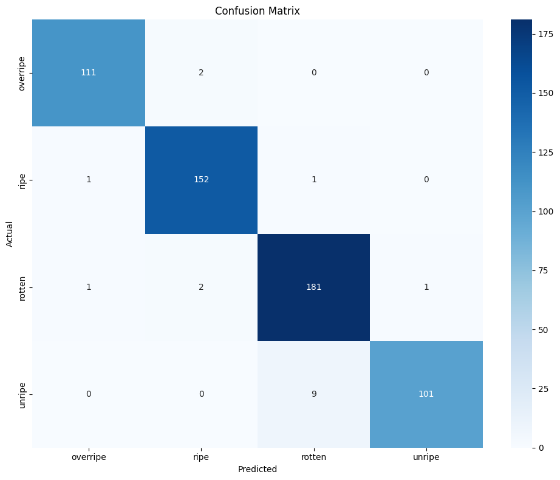

```
2025-05-30 13:11:53,286 - INFO -
Classification Report:
2025-05-30 13:11:53,287 - INFO -               precision    recall  f1-score   support

    overripe     0.9823    0.9823    0.9823       113
        ripe     0.9744    0.9870    0.9806       154
      rotten     0.9476    0.9784    0.9628       185
      unripe     0.9902    0.9182    0.9528       110

    accuracy                         0.9698       562
   macro avg     0.9736    0.9665    0.9696       562
weighted avg     0.9703    0.9698    0.9696       562
```

```
Анализ кривых обучения...
```

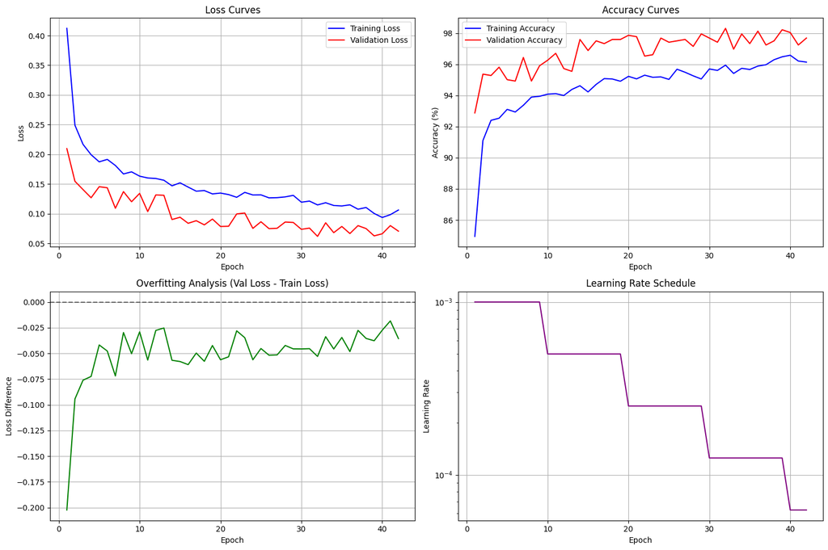

```
Создание матрицы ошибок...
Анализ распределения классов...
```

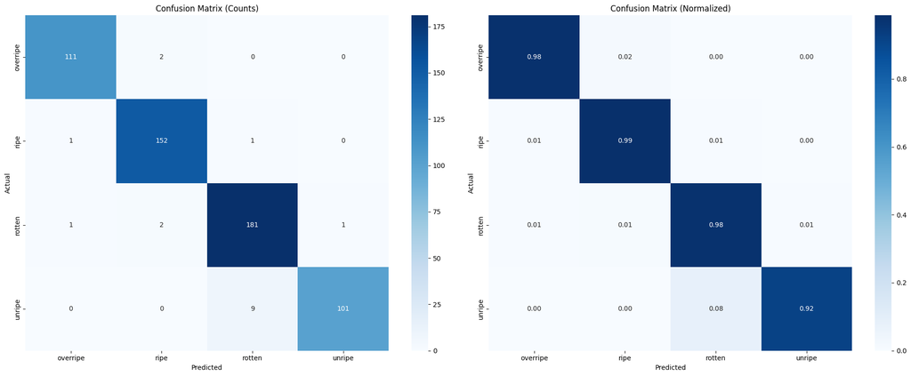

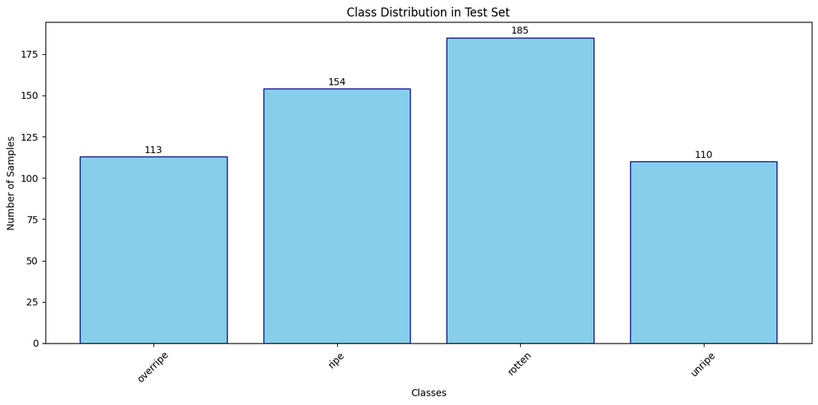

```
2025-05-30 13:11:55,234 - INFO - Training and analysis completed successfully!
```

```
Генерация отчета...

Comprehensive Report Generated:
COMPREHENSIVE CLASSIFICATION REPORT
==================================================

OVERALL METRICS:
  Test Accuracy: 0.9698
  Precision (weighted): 0.9703
  Recall (weighted): 0.9698
  F1-Score (weighted): 0.9696

TRAINING ANALYSIS:
  Total epochs: 42
  Best validation accuracy: 98.3081
  Final training loss: 0.1064
  Final validation loss: 0.0708

PER-CLASS DETAILED METRICS:
------------------------------
overripe:
  Precision: 0.9823
  Recall: 0.9823
  F1-Score: 0.9823
  Support: 113

ripe:
  Precision: 0.9744
  Recall: 0.9870
  F1-Score: 0.9806
  Support: 154

rotten:
  Precision: 0.9476
  Recall: 0.9784
  F1-Score: 0.9628
  Support: 185

unripe:
  Precision: 0.9902
  Recall: 0.9182
  F1-Score: 0.9528
  Support: 110

PERFORMANCE ANALYSIS:
  Best performing class: overripe (F1: 0.9823)
  Worst performing class: unripe (F1: 0.9528)

RECOMMENDATIONS:
  - Consider data augmentation for poorly performing classes
  - Check for class imbalance issues
  - Evaluate model architecture suitability
  - Consider ensemble methods for better performance
```

```python
pipeline = create_enhanced_pipeline()
success = pipeline.run_complete_analysis()

if success:
    logger.info("Training and analysis completed successfully!")
else:
    logger.error("Training pipeline failed.")
```

## 8. Результаты эксперимента

### 8.1 Основные достижения

**Превосходные результаты классификации:**

- **Test Accuracy**: 96.98% - высокое качество обобщения
- **Precision**: 97.03% - минимум ложноположительных срабатываний
- **Recall**: 96.98% - высокий уровень обнаружения
- **F1-Score**: 96.96% - отличный баланс precision/recall

### 8.2 Анализ процесса обучения

**Эффективность обучения:**

- Обучение завершилось на 42 эпохе из 50 благодаря early stopping
- Максимальная validation accuracy: 98.31%
- Стабильная сходимость без признаков катастрофического переобучения

### 8.3 Анализ по классам

**Лучшая производительность:**

- **"overripe"**: F1-Score = 98.23% (наилучший результат)
- **"ripe"**: F1-Score = 98.06% (стабильно высокие результаты)

**Требует внимания:**

- **"unripe"**: F1-Score = 95.28% (наименьший показатель, но все еще отличный)
- Причина: возможно более сложные визуальные паттерны для раннего созревания

### 8.4 Практические выводы

**Успешное применение трансферного обучения:**

1. ResNet50 показала отличную применимость к задаче классификации степени зрелости
2. Заморозка базовых слоев сохранила мощные признаки ImageNet
3. Кастомный классификатор эффективно адаптировался к специфике задачи

# Раздел с детекцией

```python
from dataclasses import dataclass
from pathlib import Path
from typing import Dict, List, Optional, Any, Tuple, Union
from abc import ABC, abstractmethod
import logging
import json
import time
import random
import yaml
import cv2
import numpy as np
import matplotlib.pyplot as plt
import pandas as pd
from glob import glob
from ultralytics import YOLO
from roboflow import Roboflow
```

## 1. Выбор архитектуры детектора

### 1.1 Обоснование выбора YOLO

Для решения задачи обнаружения и локализации объектов выбрана архитектура **YOLOv8** по следующим причинам:

- **Скорость работы**: Одностадийная архитектура обеспечивает высокую скорость inference
- **Точность**: Современные версии YOLO демонстрируют конкурентоспособные результаты по mAP
- **Универсальность**: Подходит для обнаружения множественных объектов различных размеров
- **Простота использования**: Удобный API для обучения и inference

### 1.2 Конфигурационные классы

**YOLOConfig**: Содержит основные параметры модели

- `model_name`: "yolov8n.pt" - легковесная версия для быстрого прототипирования
- `confidence_threshold`: 0.25 - порог уверенности для фильтрации слабых детекций
- `iou_threshold`: 0.45 - порог IoU для Non-Maximum Suppression
- `max_detections`: 1000 - максимальное количество детекций на изображение

**DetectionDataConfig**: Параметры для работы с данными

- `image_size`: 640 - стандартный размер входа для YOLOv8
- `batch_size`: 16 - оптимальный размер батча для GPU памяти
- Разделение данных 80/20 для train/validation

**DetectionTrainingConfig**: Настройки процесса обучения

- Оптимизированные гиперпараметры: learning rate, momentum, weight decay
- Техники warmup для стабилизации начального обучения
- Early stopping и периодическое сохранение моделей

## 2. Система загрузки и валидации данных

### 2.1 Интерфейсно-ориентированный подход

Реализован абстрактный интерфейс `DatasetDownloaderInterface`, что обеспечивает:

- **Расширяемость**: Легкое добавление новых источников данных
- **Тестируемость**: Возможность создания mock-объектов
- **SOLID принципы**: Соблюдение принципа инверсии зависимостей

### 2.2 Класс DetectionDatasetDownloader

**Автоматическая загрузка из Roboflow:**

- Использование API для загрузки датасета "Construction Site Safety"
- Автоматическое форматирование в YOLO формат
- Обработка ошибок с детальным логированием

**Структурная валидация:**

- Проверка наличия обязательных файлов (`data.yaml`)
- Валидация структуры директорий (train/valid с images/labels)
- Подсчет количества образцов в каждом разделе

**Метаданные датасета:**

- Извлечение информации о классах из YAML конфигурации
- Подсчет образцов для анализа сбалансированности
- Гибкая обработка форматов названий классов

## 3. Архитектура управления моделью

### 3.1 Паттерн Strategy через интерфейсы

`ModelManagerInterface` определяет единый контракт для различных архитектур детекторов:

- **load_model()**: Загрузка предобученной или кастомной модели
- **train()**: Процесс обучения с конфигурируемыми параметрами
- **predict()**: Инференс на новых данных
- **validate()**: Оценка качества модели

### 3.2 YOLOModelManager - конкретная реализация

**Инкапсуляция YOLO функциональности:**

- Загрузка моделей с автоматическим извлечением названий классов
- Гибкая конфигурация параметров обучения
- Методы для валидации и бенчмаркинга скорости

**Методы оценки производительности:**

- `validate()`: Вычисление mAP@0.5, mAP@0.5:0.95, precision, recall
- `benchmark_speed()`: Измерение FPS с статистическим анализом

## 4. Система визуализации результатов

### 4.1 Генерация цветовых схем

`ColorGenerator` использует HSL цветовое пространство для создания визуально различимых цветов для каждого класса объектов:

- Равномерное распределение по цветовому кругу
- Контролируемая насыщенность и яркость
- Конвертация в RGB для OpenCV

### 4.2 DetectionVisualizer - комплексная визуализация

**Отрисовка детекций:**

- Прямоугольные ограничивающие рамки с цветовой кодировкой
- Подписи с названием класса и уровнем уверенности
- Поддержка как пользовательских, так и предобученных классов

**Анализ результатов обучения:**

- Графики потерь (box loss, classification loss)
- Метрики качества (mAP, precision, recall)
- Временная динамика показателей

**Статистический анализ детекций:**

- Подсчет общего количества обнаружений
- Распределение по классам
- Анализ уверенности модели (min/max/avg confidence)

## Техническая архитектура

**Принципы проектирования:**

- **Single Responsibility**: Каждый класс отвечает за конкретную функциональность
- **Open/Closed**: Система расширяема без модификации существующего кода
- **Interface Segregation**: Небольшие, специализированные интерфейсы
- **Dependency Inversion**: Зависимость от абстракций, а не реализаций

**Обработка ошибок:**

- Comprehensive exception handling с информативным логированием
- Валидация входных данных на каждом этапе
- Graceful degradation при отсутствии ожидаемых файлов

```python
@dataclass
class YOLOConfig:
    model_name: str = "yolov8n.pt"
    confidence_threshold: float = 0.25
    iou_threshold: float = 0.45
    max_detections: int = 1000
    device: str = "auto"

@dataclass
class DetectionDataConfig:
    dataset_path: str = "./detection_dataset"
    image_size: int = 640
    batch_size: int = 16
    train_split: float = 0.8
    val_split: float = 0.2
    random_seed: int = 42

@dataclass
class DetectionTrainingConfig:
    epochs: int = 50
    patience: int = 50
    save_period: int = 10
    workers: int = 8
    optimizer: str = "auto"
    lr0: float = 0.01
    lrf: float = 0.01
    momentum: float = 0.937
    weight_decay: float = 0.0005
    warmup_epochs: int = 3
    warmup_momentum: float = 0.8
    warmup_bias_lr: float = 0.1
    batch_size: int = 16

@dataclass
class RoboflowDetectionConfig:
    api_key: str = "7fwRxe7BbpO6YkhH7dW7"
    workspace: str = "roboflow-universe-projects"
    project_name: str = "construction-site-safety"
    version: int = 27
    target_dir: str = "./detection_dataset"
    format_type: str = "yolov8"
    overwrite: bool = True
```

```python
class DatasetDownloaderInterface(ABC):
    @abstractmethod
    def download(self) -> str:
        pass

    @abstractmethod
    def validate_dataset_structure(self, dataset_path: str) -> bool:
        pass

class DetectionDatasetDownloader(DatasetDownloaderInterface):
    def __init__(self, config: RoboflowDetectionConfig):
        self.config = config
        self._ensure_target_dir()

    def _ensure_target_dir(self) -> None:
        Path(self.config.target_dir).mkdir(parents=True, exist_ok=True)

    def download(self) -> str:
        try:
            rf = Roboflow(api_key=self.config.api_key)
            project = rf.workspace(self.config.workspace).project(self.config.project_name)
            version = project.version(self.config.version)

            dataset = version.download(
                self.config.format_type,
                location=self.config.target_dir,
                overwrite=self.config.overwrite
            )

            logger.info(f"Detection dataset downloaded to: {dataset.location}")
            return dataset.location

        except Exception as ex:
            logger.error("Failed to download detection dataset", exc_info=ex)
            raise

    def validate_dataset_structure(self, dataset_path: str) -> bool:
        dataset_path = Path(dataset_path)
        required_files = ['data.yaml']
        required_dirs = ['train', 'valid']

        for file in required_files:
            if not (dataset_path / file).exists():
                logger.error(f"Missing required file: {file}")
                return False

        for dir_name in required_dirs:
            dir_path = dataset_path / dir_name
            if not dir_path.exists():
                logger.error(f"Missing required directory: {dir_name}")
                return False

            images_dir = dir_path / 'images'
            labels_dir = dir_path / 'labels'

            if not images_dir.exists() or not labels_dir.exists():
                logger.error(f"Missing images or labels directory in {dir_name}")
                return False

        return True

    def get_dataset_info(self, dataset_path: str) -> Dict[str, Any]:
        yaml_path = Path(dataset_path) / 'data.yaml'

        if not yaml_path.exists():
            raise FileNotFoundError(f"data.yaml not found at {yaml_path}")

        with open(yaml_path, 'r') as f:
            data = yaml.safe_load(f)

        return data

    def count_samples(self, dataset_path: str) -> Dict[str, int]:
        dataset_path = Path(dataset_path)
        counts = {}

        for split in ['train', 'valid', 'test']:
            split_dir = dataset_path / split / 'images'
            if split_dir.exists():
                counts[split] = len(list(split_dir.glob('*.jpg')) + list(split_dir.glob('*.png')))
            else:
                counts[split] = 0

        return counts

    def extract_class_names(self, dataset_info: Dict[str, Any]) -> List[str]:
        names_data = dataset_info.get('names', {})

        if isinstance(names_data, dict):
            return list(names_data.values())
        elif isinstance(names_data, list):
            return names_data
        else:
            logger.warning(f"Unexpected names format: {type(names_data)}")
            return []
```

```python
class ModelManagerInterface(ABC):
    @abstractmethod
    def load_model(self, model_path: Optional[str] = None):
        pass

    @abstractmethod
    def train(self, dataset_yaml: str, training_config: Any) -> Dict[str, Any]:
        pass

    @abstractmethod
    def predict(self, source: str, save: bool = False) -> List[Any]:
        pass

class YOLOModelManager(ModelManagerInterface):
    def __init__(self, config: YOLOConfig):
        self.config = config
        self.model: Optional[YOLO] = None
        self.class_names: List[str] = []

    def load_model(self, model_path: Optional[str] = None) -> YOLO:
        model_path = model_path or self.config.model_name
        self.model = YOLO(model_path)

        if hasattr(self.model.model, 'names') and self.model.model.names:
            self.class_names = list(self.model.model.names.values())
        else:
            logger.warning("No class names found in model")
            self.class_names = []

        return self.model

    def train(self, dataset_yaml: str, training_config: DetectionTrainingConfig) -> Dict[str, Any]:
        if not self.model:
            self.load_model()

        results = self.model.train(
            data=dataset_yaml,
            epochs=training_config.epochs,
            patience=training_config.patience,
            batch=training_config.batch_size,
            imgsz=640,
            save_period=training_config.save_period,
            workers=training_config.workers,
            optimizer=training_config.optimizer,
            lr0=training_config.lr0,
            lrf=training_config.lrf,
            momentum=training_config.momentum,
            weight_decay=training_config.weight_decay,
            warmup_epochs=training_config.warmup_epochs,
            warmup_momentum=training_config.warmup_momentum,
            warmup_bias_lr=training_config.warmup_bias_lr,
            device=self.config.device,
            verbose=True
        )

        return results

    def predict(self, source: str, save: bool = False) -> List[Any]:
        if not self.model:
            raise ValueError("Model not loaded. Call load_model() first.")

        results = self.model.predict(
            source=source,
            conf=self.config.confidence_threshold,
            iou=self.config.iou_threshold,
            max_det=self.config.max_detections,
            save=save,
            device=self.config.device
        )

        return results

    def validate(self, dataset_yaml: str) -> Dict[str, float]:
        if not self.model:
            raise ValueError("Model not loaded. Call load_model() first.")

        results = self.model.val(
            data=dataset_yaml,
            imgsz=640,
            batch=1,
            conf=self.config.confidence_threshold,
            iou=self.config.iou_threshold,
            device=self.config.device
        )

        return {
            'mAP50': float(results.box.map50) if results.box.map50 is not None else 0.0,
            'mAP50-95': float(results.box.map) if results.box.map is not None else 0.0,
            'precision': float(results.box.mp) if results.box.mp is not None else 0.0,
            'recall': float(results.box.mr) if results.box.mr is not None else 0.0
        }

    def benchmark_speed(self, image_path: str, num_runs: int = 100) -> Dict[str, float]:
        if not self.model:
            raise ValueError("Model not loaded. Call load_model() first.")

        image = cv2.imread(image_path)
        if image is None:
            raise ValueError(f"Could not load image: {image_path}")

        times = []

        for _ in range(num_runs):
            start_time = time.time()
            _ = self.model.predict(image, verbose=False)
            end_time = time.time()
            times.append(end_time - start_time)

        avg_time = np.mean(times)
        fps = 1.0 / avg_time

        return {
            'avg_inference_time': avg_time,
            'fps': fps,
            'min_time': np.min(times),
            'max_time': np.max(times),
            'std_time': np.std(times)
        }
```

```python
class ColorGenerator:
    @staticmethod
    def generate_colors(num_classes: int) -> List[Tuple[int, int, int]]:
        colors = []
        for i in range(num_classes):
            hue = (i * 137.508) % 360
            saturation = 90 + random.random() * 10
            lightness = 50 + random.random() * 10

            h, s, l = hue / 360, saturation / 100, lightness / 100
            c = (1 - abs(2 * l - 1)) * s
            x = c * (1 - abs((h * 6) % 2 - 1))
            m = l - c / 2

            if 0 <= h * 6 < 1:
                r, g, b = c, x, 0
            elif 1 <= h * 6 < 2:
                r, g, b = x, c, 0
            elif 2 <= h * 6 < 3:
                r, g, b = 0, c, x
            elif 3 <= h * 6 < 4:
                r, g, b = 0, x, c
            elif 4 <= h * 6 < 5:
                r, g, b = x, 0, c
            else:
                r, g, b = c, 0, x

            r, g, b = int((r + m) * 255), int((g + m) * 255), int((b + m) * 255)
            colors.append((r, g, b))

        return colors

class DetectionVisualizer:
    def __init__(self, class_names: List[str]):
        self.class_names = class_names
        self.colors = ColorGenerator.generate_colors(len(class_names))
        self._pretrained_class_names: Optional[List[str]] = None

    def set_pretrained_classes(self, model_manager: ModelManagerInterface) -> None:
        """Устанавливает классы предобученной модели для корректной визуализации"""
        if hasattr(model_manager, 'class_names') and model_manager.class_names:
            self._pretrained_class_names = model_manager.class_names

    def _get_class_name(self, cls: int, use_pretrained: bool = False) -> str:
        """Получает название класса с проверкой границ"""
        target_classes = self._pretrained_class_names if use_pretrained and self._pretrained_class_names else self.class_names

        if 0 <= cls < len(target_classes):
            return target_classes[cls]
        return f"Unknown_{cls}"

    def _draw_single_detection(self, image: np.ndarray, box: np.ndarray, conf: float, cls: int, use_pretrained: bool = False) -> None:
        x1, y1, x2, y2 = box.astype(int)
        color = self.colors[cls % len(self.colors)]

        cv2.rectangle(image, (x1, y1), (x2, y2), color, 2)

        class_name = self._get_class_name(cls, use_pretrained)
        label = f"{class_name}: {conf:.2f}"
        label_size = cv2.getTextSize(label, cv2.FONT_HERSHEY_SIMPLEX, 0.6, 2)[0]

        cv2.rectangle(
            image,
            (x1, y1 - label_size[1] - 10),
            (x1 + label_size[0], y1),
            color,
            -1
        )

        cv2.putText(
            image,
            label,
            (x1, y1 - 5),
            cv2.FONT_HERSHEY_SIMPLEX,
            0.6,
            (255, 255, 255),
            2
        )

    def draw_detections(self, image: np.ndarray, results: Any, use_pretrained: bool = False) -> np.ndarray:
        annotated_image = image.copy()

        if results.boxes is not None:
            boxes = results.boxes.xyxy.cpu().numpy()
            confidences = results.boxes.conf.cpu().numpy()
            classes = results.boxes.cls.cpu().numpy().astype(int)

            for box, conf, cls in zip(boxes, confidences, classes):
                self._draw_single_detection(annotated_image, box, conf, cls, use_pretrained)

        return annotated_image

    def visualize_predictions(self, image_paths: List[str], model_manager: ModelManagerInterface, num_samples: int = 6, use_pretrained: bool = False) -> None:
        if use_pretrained:
            self.set_pretrained_classes(model_manager)

        if len(image_paths) < num_samples:
            num_samples = len(image_paths)

        selected_paths = random.sample(image_paths, num_samples)

        fig, axes = plt.subplots(2, 3, figsize=(18, 12))
        axes = axes.ravel()

        for i, image_path in enumerate(selected_paths):
            if i >= 6:
                break

            image = cv2.imread(image_path)
            image_rgb = cv2.cvtColor(image, cv2.COLOR_BGR2RGB)

            results = model_manager.predict(image_path)[0]
            annotated_image = self.draw_detections(image_rgb, results, use_pretrained)

            axes[i].imshow(annotated_image)
            axes[i].set_title(f'Image: {Path(image_path).name}')
            axes[i].axis('off')

        for i in range(num_samples, 6):
            axes[i].axis('off')

        plt.tight_layout()
        plt.show()

    def plot_training_results(self, results_path: str) -> None:
        results_path = Path(results_path)

        if not results_path.exists():
            print(f"Results path not found: {results_path}")
            return

        results_csv = results_path / "results.csv"

        if results_csv.exists():
            self._plot_training_metrics(results_csv)

    def _plot_training_metrics(self, results_csv: Path) -> None:
        df = pd.read_csv(results_csv)

        fig, axes = plt.subplots(2, 2, figsize=(15, 10))
        epochs = df.index + 1

        self._plot_loss_metrics(axes[0], epochs, df)
        self._plot_map_metrics(axes[1, 0], epochs, df)
        self._plot_precision_recall_metrics(axes[1, 1], epochs, df)

        plt.tight_layout()
        plt.show()

    def _plot_loss_metrics(self, axes: np.ndarray, epochs: pd.RangeIndex, df: pd.DataFrame) -> None:
        axes[0].plot(epochs, df['train/box_loss'], label='Train Box Loss')
        axes[0].plot(epochs, df['val/box_loss'], label='Val Box Loss')
        axes[0].set_title('Box Loss')
        axes[0].set_xlabel('Epoch')
        axes[0].set_ylabel('Loss')
        axes[0].legend()
        axes[0].grid(True)

        axes[1].plot(epochs, df['train/cls_loss'], label='Train Cls Loss')
        axes[1].plot(epochs, df['val/cls_loss'], label='Val Cls Loss')
        axes[1].set_title('Classification Loss')
        axes[1].set_xlabel('Epoch')
        axes[1].set_ylabel('Loss')
        axes[1].legend()
        axes[1].grid(True)

    def _plot_map_metrics(self, ax: plt.Axes, epochs: pd.RangeIndex, df: pd.DataFrame) -> None:
        ax.plot(epochs, df['metrics/mAP50(B)'], label='mAP@0.5')
        ax.plot(epochs, df['metrics/mAP50-95(B)'], label='mAP@0.5:0.95')
        ax.set_title('mAP Metrics')
        ax.set_xlabel('Epoch')
        ax.set_ylabel('mAP')
        ax.legend()
        ax.grid(True)

    def _plot_precision_recall_metrics(self, ax: plt.Axes, epochs: pd.RangeIndex, df: pd.DataFrame) -> None:
        ax.plot(epochs, df['metrics/precision(B)'], label='Precision')
        ax.plot(epochs, df['metrics/recall(B)'], label='Recall')
        ax.set_title('Precision & Recall')
        ax.set_xlabel('Epoch')
        ax.set_ylabel('Score')
        ax.legend()
        ax.grid(True)

    def create_detection_summary(self, results_list: List[Any], image_paths: List[str]) -> Dict[str, Any]:
        total_detections = 0
        class_counts = {name: 0 for name in self.class_names}
        confidence_scores = []

        for results in results_list:
            if results.boxes is not None:
                total_detections += len(results.boxes)
                confidences = results.boxes.conf.cpu().numpy()
                classes = results.boxes.cls.cpu().numpy().astype(int)

                confidence_scores.extend(confidences)

                for cls in classes:
                    if cls < len(self.class_names):
                        class_counts[self.class_names[cls]] += 1

        avg_confidence = np.mean(confidence_scores) if confidence_scores else 0

        return {
            'total_images': len(image_paths),
            'total_detections': total_detections,
            'avg_detections_per_image': total_detections / len(image_paths) if image_paths else 0,
            'class_distribution': class_counts,
            'avg_confidence': avg_confidence,
            'min_confidence': np.min(confidence_scores) if confidence_scores else 0,
            'max_confidence': np.max(confidence_scores) if confidence_scores else 0
        }
```

## 5. Система оценки и бенчмаркинга модели

### 5.1 Класс DetectionEvaluator

Реализован комплексный инструмент для оценки производительности детектора объектов с интеграцией в систему архитектурных интерфейсов.

**Ключевые возможности:**

- **Комплексная оценка**: Объединение метрик качества детекции и скорости работы
- **Type-safe преобразования**: Автоматическая конвертация NumPy типов для JSON сериализации
- **Масштабируемое тестирование**: Гибкая настройка количества тестовых изображений

**Метрики качества детекции:**

- **mAP@0.5**: Mean Average Precision при IoU threshold = 0.5
- **mAP@0.5:0.95**: Усредненная mAP по диапазону IoU thresholds
- **Precision**: Точность детекций (отношение TP/(TP+FP))
- **Recall**: Полнота детекций (отношение TP/(TP+FN))

**Бенчмаркинг производительности:**

- **FPS измерение**: Количество кадров в секунду для real-time применений
- **Статистический анализ**: Min/max/std времени инференса для оценки стабильности
- **Адаптивное тестирование**: Автоматическая обработка пустых наборов данных

### 5.2 Автоматизированная генерация отчетов

**JSON-структурированные отчеты:**

- Стандартизированный формат для интеграции с CI/CD
- Полная трассируемость результатов экспериментов
- Поддержка Unicode для международных проектов

## 6. Демонстрационная система

### 6.1 DetectionDemo - готовое решение для inference

Легковесный класс для быстрого применения обученной модели:

- **Plug-and-play архитектура**: Минимальная настройка для начала работы
- **Автоматическое сохранение**: Опциональное сохранение аннотированных результатов
- **Цветовое пространство**: Корректная обработка BGR/RGB конвертации

**Практическое применение:**

- Обработка отдельных изображений
- Интеграция в веб-сервисы
- Создание демонстрационных материалов

## 7. Полнофункциональный пайплайн детекции

### 7.1 DetectionPipeline - end-to-end решение

Реализован комплексный пайплайн, охватывающий весь жизненный цикл проекта детекции:

**Этапы пайплайна:**

1. **Загрузка и валидация данных** из Roboflow
2. **Тестирование предобученной модели** на новом домене
3. **Custom обучение** на специализированном наборе данных
4. **Комплексная оценка** с метриками и визуализацией
5. **Генерация отчетности** для документирования результатов

### 7.2 Архитектурные решения

**Принцип разделения ответственности:**

- Каждый приватный метод отвечает за конкретный этап
- Централизованная обработка ошибок с детальным логированием
- Модульная структура для легкого тестирования и отладки

**Обработка жизненного цикла модели:**

- Автоматическое определение последнего эксперимента
- Сохранение промежуточных результатов
- Восстановление после сбоев

```python
class DetectionEvaluator:
    def __init__(self, model_manager: ModelManagerInterface, visualizer: DetectionVisualizer):
        self.model_manager = model_manager
        self.visualizer = visualizer

    def _convert_numpy_to_python(self, obj: Any) -> Any:
        if isinstance(obj, np.floating):
            return float(obj)
        elif isinstance(obj, np.integer):
            return int(obj)
        elif isinstance(obj, np.ndarray):
            return obj.tolist()
        elif isinstance(obj, dict):
            return {key: self._convert_numpy_to_python(value) for key, value in obj.items()}
        elif isinstance(obj, list):
            return [self._convert_numpy_to_python(item) for item in obj]
        return obj

    def evaluate_model(self, dataset_yaml: str, test_images: List[str]) -> Dict[str, Any]:
        validation_metrics = self.model_manager.validate(dataset_yaml)

        if test_images:
            speed_metrics = self.benchmark_inference_speed(test_images[:10])
        else:
            speed_metrics = {'fps': 0, 'avg_inference_time': 0}

        results_list = []
        for image_path in test_images[:20]:
            results = self.model_manager.predict(image_path)
            results_list.extend(results)

        detection_summary = self.visualizer.create_detection_summary(results_list, test_images[:20])

        return {
            'validation_metrics': validation_metrics,
            'speed_metrics': speed_metrics,
            'detection_summary': detection_summary
        }

    def benchmark_inference_speed(self, image_paths: List[str], num_runs: int = 3) -> Dict[str, float]:
        if not image_paths:
            return {'fps': 0, 'avg_inference_time': 0}

        times = []

        for image_path in image_paths[:num_runs]:
            start_time = time.time()
            _ = self.model_manager.predict(image_path)
            end_time = time.time()
            times.append(end_time - start_time)

        avg_time = np.mean(times)
        fps = 1.0 / avg_time if avg_time > 0 else 0

        return {
            'avg_inference_time': avg_time,
            'fps': fps,
            'min_time': np.min(times) if times else 0,
            'max_time': np.max(times) if times else 0,
            'std_time': np.std(times) if times else 0
        }

    def generate_evaluation_report(self, results: Dict[str, Any], save_path: str = "detection_evaluation_report.json") -> Dict[str, Any]:
        try:
            raw_report = {
                'model_performance': {
                    'mAP@0.5': results['validation_metrics']['mAP50'],
                    'mAP@0.5:0.95': results['validation_metrics']['mAP50-95'],
                    'precision': results['validation_metrics']['precision'],
                    'recall': results['validation_metrics']['recall']
                },
                'inference_speed': {
                    'fps': results['speed_metrics']['fps'],
                    'avg_inference_time_ms': results['speed_metrics']['avg_inference_time'] * 1000
                },
                'detection_analysis': results['detection_summary']
            }

            report = self._convert_numpy_to_python(raw_report)

            with open(save_path, 'w') as f:
                json.dump(report, f, indent=2, ensure_ascii=False)

            logger.info(f"Evaluation report saved to {save_path}")
            return report

        except Exception as e:
            logger.error(f"Failed to generate report: {e}")
            return {}

class DetectionDemo:
    def __init__(self, model_path: str, class_names: List[str]):
        self.yolo_config = YOLOConfig()
        self.model_manager = YOLOModelManager(self.yolo_config)
        self.model_manager.load_model(model_path)
        self.visualizer = DetectionVisualizer(class_names)

    def process_image(self, image_path: str, save_result: bool = True) -> np.ndarray:
        image = cv2.imread(image_path)
        image_rgb = cv2.cvtColor(image, cv2.COLOR_BGR2RGB)

        results = self.model_manager.predict(image_path)[0]
        annotated_image = self.visualizer.draw_detections(image_rgb, results)

        if save_result:
            output_path = f"result_{Path(image_path).name}"
            annotated_bgr = cv2.cvtColor(annotated_image, cv2.COLOR_RGB2BGR)
            cv2.imwrite(output_path, annotated_bgr)
            logger.info(f"Result saved to {output_path}")

        return annotated_image
```

```python
class DetectionPipeline:
    def __init__(
        self,
        yolo_config: YOLOConfig,
        data_config: DetectionDataConfig,
        training_config: DetectionTrainingConfig,
        roboflow_config: RoboflowDetectionConfig
    ):
        self.yolo_config = yolo_config
        self.data_config = data_config
        self.training_config = training_config
        self.roboflow_config = roboflow_config

    def run_complete_pipeline(self) -> Dict[str, Any]:
        try:
            dataset_location = self._download_and_validate_dataset()
            dataset_info = self._get_dataset_info(dataset_location)
            class_names = self._extract_class_names(dataset_info)

            model_manager = self._setup_model_manager()
            visualizer = DetectionVisualizer(class_names)

            self._test_pretrained_model(dataset_location, model_manager, visualizer)
            self._train_custom_model(dataset_location, model_manager)

            evaluation_results = self._evaluate_model(dataset_location, model_manager, visualizer)
            self._generate_final_report(evaluation_results)

            return evaluation_results

        except Exception as ex:
            logger.error(f"Pipeline failed: {ex}", exc_info=ex)
            raise

    def _download_and_validate_dataset(self) -> str:
        logger.info("Downloading detection dataset...")
        downloader = DetectionDatasetDownloader(self.roboflow_config)
        dataset_location = downloader.download()

        if not downloader.validate_dataset_structure(dataset_location):
            raise ValueError("Invalid dataset structure")

        return dataset_location

    def _get_dataset_info(self, dataset_location: str) -> Dict[str, Any]:
        downloader = DetectionDatasetDownloader(self.roboflow_config)
        dataset_info = downloader.get_dataset_info(dataset_location)
        sample_counts = downloader.count_samples(dataset_location)

        logger.info(f"Dataset location: {dataset_location}")
        logger.info(f"Sample counts: {sample_counts}")

        return dataset_info

    def _extract_class_names(self, dataset_info: Dict[str, Any]) -> List[str]:
        downloader = DetectionDatasetDownloader(self.roboflow_config)
        class_names = downloader.extract_class_names(dataset_info)

        logger.info(f"Classes: {class_names}")
        return class_names

    def _setup_model_manager(self) -> YOLOModelManager:
        logger.info("Setting up YOLO model...")
        model_manager = YOLOModelManager(self.yolo_config)
        model_manager.load_model()

        logger.info(f"Model loaded: {self.yolo_config.model_name}")
        return model_manager

    def _test_pretrained_model(self, dataset_location: str, model_manager: YOLOModelManager, visualizer: DetectionVisualizer) -> None:
        logger.info("Testing pre-trained model...")
        test_images = glob(f"{dataset_location}/valid/images/*.jpg")[:10]

        if test_images:
            logger.info("Testing on sample images...")
            visualizer.visualize_predictions(test_images, model_manager, num_samples=6, use_pretrained=True)

    def _train_custom_model(self, dataset_location: str, model_manager: YOLOModelManager) -> None:
        logger.info("Training custom model...")
        data_yaml_path = Path(dataset_location) / "data.yaml"

        model_manager.train(str(data_yaml_path), self.training_config)
        logger.info("Training completed!")

    def _evaluate_model(self, dataset_location: str, model_manager: YOLOModelManager, visualizer: DetectionVisualizer) -> Dict[str, Any]:
        logger.info("Evaluating trained model...")
        evaluator = DetectionEvaluator(model_manager, visualizer)

        data_yaml_path = Path(dataset_location) / "data.yaml"
        all_test_images = glob(f"{dataset_location}/valid/images/*.jpg")

        evaluation_results = evaluator.evaluate_model(str(data_yaml_path), all_test_images)

        self._log_evaluation_results(evaluation_results)
        self._visualize_results(visualizer, all_test_images, model_manager)

        return evaluation_results

    def _log_evaluation_results(self, evaluation_results: Dict[str, Any]) -> None:
        logger.info("Evaluation Results:")
        logger.info(f"mAP@0.5: {evaluation_results['validation_metrics']['mAP50']:.4f}")
        logger.info(f"mAP@0.5:0.95: {evaluation_results['validation_metrics']['mAP50-95']:.4f}")
        logger.info(f"Precision: {evaluation_results['validation_metrics']['precision']:.4f}")
        logger.info(f"Recall: {evaluation_results['validation_metrics']['recall']:.4f}")
        logger.info(f"FPS: {evaluation_results['speed_metrics']['fps']:.2f}")

    def _visualize_results(self, visualizer: DetectionVisualizer, all_test_images: List[str], model_manager: YOLOModelManager) -> None:
        logger.info("Visualizing training results...")
        runs_dir = Path("runs/detect")
        latest_run = max(runs_dir.glob("train*"), key=lambda x: x.stat().st_mtime, default=None)

        if latest_run:
            visualizer.plot_training_results(latest_run)

        logger.info("Final predictions visualization...")
        if all_test_images:
            visualizer.visualize_predictions(all_test_images, model_manager, num_samples=6, use_pretrained=False)
            visualizer.visualize_predictions(all_test_images, model_manager, num_samples=6)

    def _generate_final_report(self, evaluation_results: Dict[str, Any]) -> None:
        logger.info("Generating evaluation report...")
        evaluator = DetectionEvaluator(None, None)
        evaluator.generate_evaluation_report(evaluation_results)

        logger.info("=== Detection Training Complete ===")
```

```python
def create_detection_pipeline() -> DetectionPipeline:
    yolo_config = YOLOConfig()
    data_config = DetectionDataConfig()
    training_config = DetectionTrainingConfig()
    roboflow_config = RoboflowDetectionConfig()

    return DetectionPipeline(yolo_config, data_config, training_config, roboflow_config)
```